# Master 2 Biologie Santé

## Variance explained by each axis

Eigenvalues (*Valeurs propres*)

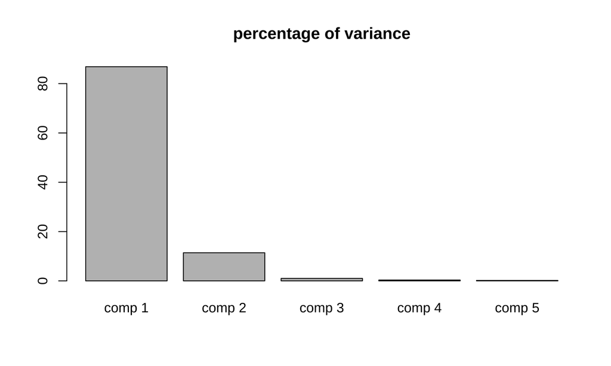

## Graph of variables

Since data are standardized, variables are contained in a **multidimensional sphere** centered and of radius 1.

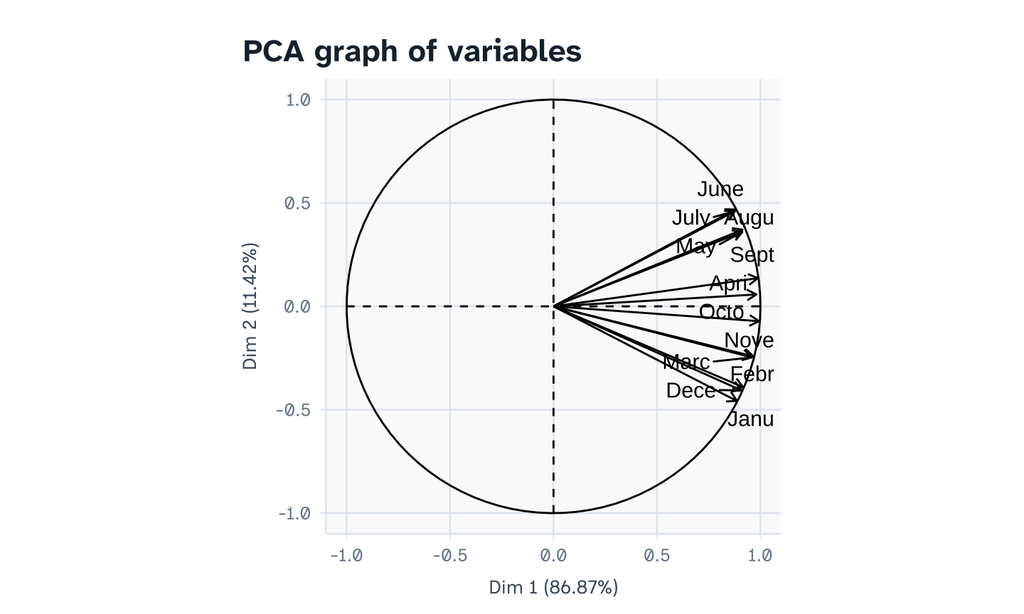

## Supplementary variables

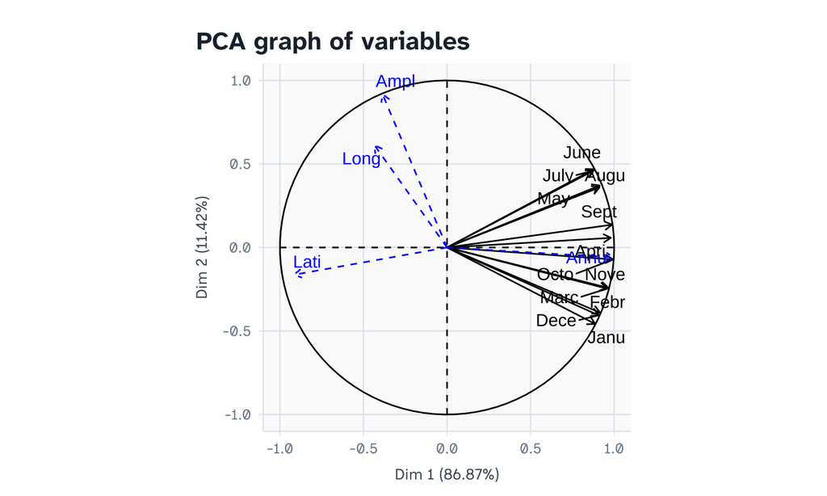

## Conclusion on PCA analysis

The Principal Component Analysis allow to obtain a **synthetic vision** of the data by **projecting** and **rotating** data cloud on appropriate plans.

It allows the **discovery** of

- **Groups of individuals** through data dimensionality
- **Correlated and independant variables** and
- **What variables** explain the data ?

\(\Longrightarrow\) Use for Gene expression data measured by RNA-seq.

## Conclusion on PCA analysis

There are **3 basics information types** that we obtain from a PCA analysis

- **PC scores** - these are the coordinates of our samples on the new PC axis
- **Eigenvalues** (French: Valeurs propres) - these represent the variance explained by each PC. We can use these to calculate the proportion of variance in the original data that each axis explains. Dividing an eigenvalue by the sum of all eigenvalues gives the percentage of variance explained by the axis.
- **Variable loadings (*eigenvectors*)** (French: Vecteurs propres) - these reflect the “weight” that each variable has on a particular PC. These can be thought of as the correlation between the PC and the original variable.

## Applications in transcriptomics

## Analysis of transcriptome data

Transcriptomics is the analysis of **gene expression** in biological systems. It can be done with two high-throughout technologies: **cDNA Microarrays** and **RNA-seq**.

It fundamentally works by **comparison** of at least **two** conditions: for example, **two experiments** or **one experiments and a control**.

It starts by designing an experiments in which we will define:

- What experimental conditions we wish to compare
- The number of replicates per experimental conditions

**Reference:** J Quackenbush. Computational Approaches to Analysis of DNA Microarray Data (2008).

## Transcriptomics data bioinformatics pipeline

1. Sequencing and Sequence quality control
2. Alignment (With **STAR**) and feature counting (**featureCount**)
3. Main quality assessment (*PCA* can be used here)
4. Data analysis:
- **Supervised**: search for **Differentially expressed genes (DE)**
- **Unsupervised**: search for **Groups of genes or samples** (*Clustering*)

## RNA-seq Principle

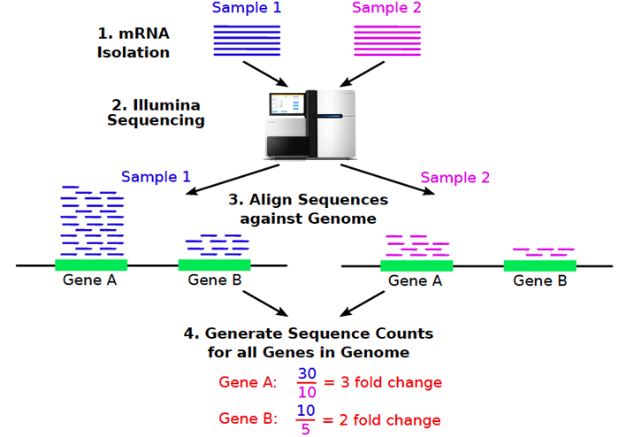

Source: Thomas Girke, *Analysis of RNA-Seq Data with R/Bioconductor*

## Transcriptomics data structure

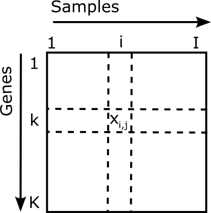

- **Rows**: gene expression profiles
- **Columns**: patients/samples, etc…
- ! Opposite of previous data organisation

## Example: Dataset GSE130657 from Yusenko *et al*

We will be working with the data from Yusenko *et al*: ‘Expression profiling by high throughput sequencing of THP-1 cells treated with Monensin’.

Data is available in the **Gene Expression Omnibus** database, accession number **GSE130657**.

https://www.ncbi.nlm.nih.gov/geo/query/acc.cgi?acc=GSE130657

## Dataset GSE130657

It is organized as follows:

| SRA | GEO | Treatment | Sample |
| --- | --- | --- | --- |
| SRR9005674 | GSM3746500 | THP0 | 1 |
| SRR9005675 | GSM3746501 | THP0 | 2 |
| SRR9005676 | GSM3746502 | THP0 | 3 |
| SRR9005677 | GSM3746503 | M | 1 |
| SRR9005678 | GSM3746504 | M | 2 |
| SRR9005679 | GSM3746505 | M | 3 |

- **THP0**: Control
- **M**: Cell treated with Monensin.

## Preprocessing

- **TMM Normalization** and **Log-transformation**
- Keep genes meeting the following conditions
  - Expressed by a count of at least **15** in **2 samples** in **each group**
  - Expressed by a total count of at least **100**
  - Having a identifier `entrezgene` and `hgnc_symbol`

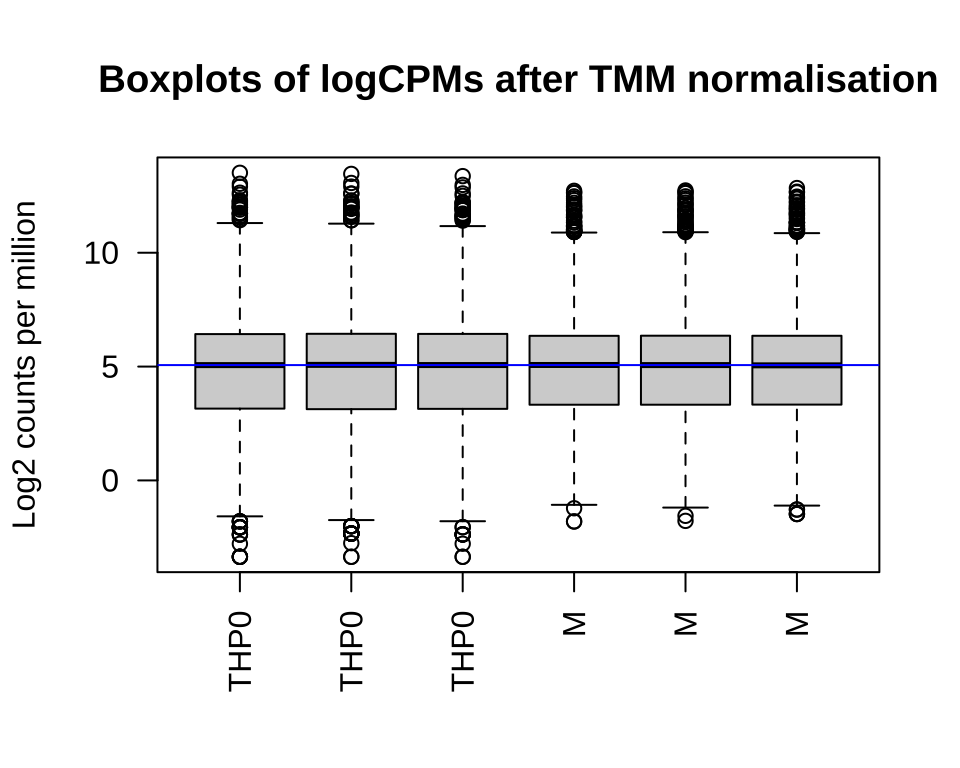

## PCA of samples

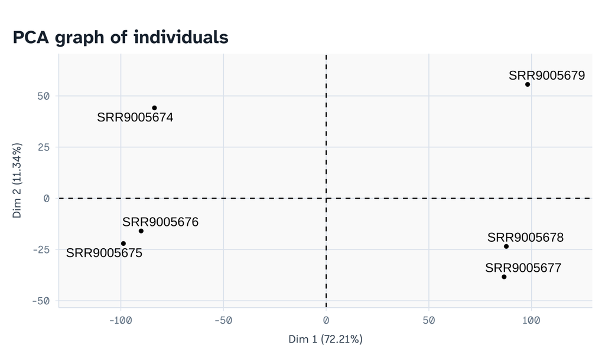

## PCA of samples with groups

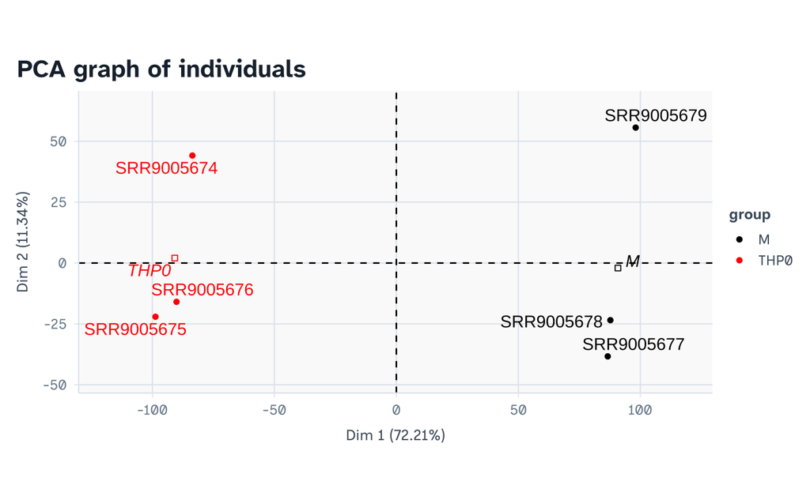

## Eigenvalues

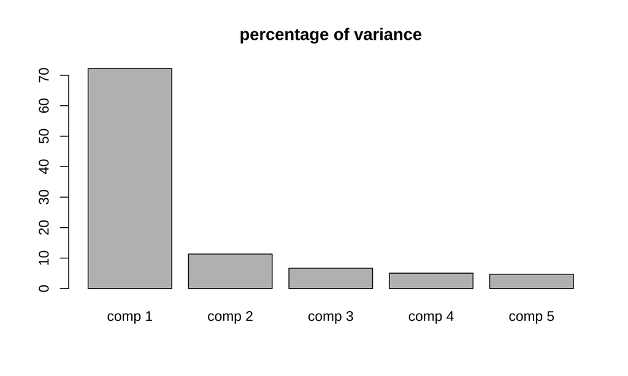

## Loadings

*loadings* = contributions of variables (genes) to each PC

[output not shown]

[output cut: 11413 more lines]

[output not shown]

|  | Dim.1 | Dim.2 | Dim.3 | Dim.4 | Dim.5 |
| --- | --- | --- | --- | --- | --- |
| TSPAN6 | 0.0112610 | 0.0000098 | 0.0030051 | 0.0018782 | 0.0062113 |
| DPM1 | 0.0092617 | 0.0000002 | 0.0227409 | 0.0096151 | 0.0005856 |
| SCYL3 | 0.0004883 | 0.0013336 | 0.0340003 | 0.0335108 | 0.0902966 |
| C1orf112 | 0.0119009 | 0.0005746 | 0.0002567 | 0.0007207 | 0.0001772 |
| FGR | 0.0120595 | 0.0000003 | 0.0000420 | 0.0000576 | 0.0001471 |
| FUCA2 | 0.0091823 | 0.0162602 | 0.0010130 | 0.0003056 | 0.0034506 |
| GCLC | 0.0094108 | 0.0136730 | 0.0011136 | 0.0040636 | 0.0019970 |
| NFYA | 0.0120502 | 0.0000085 | 0.0000197 | 0.0000540 | 0.0003047 |
| STPG1 | 0.0094951 | 0.0000747 | 0.0113964 | 0.0143755 | 0.0078028 |
| NIPAL3 | 0.0104086 | 0.0000154 | 0.0154076 | 0.0017765 | 0.0017876 |

We extract genes with highest **loadings** in PC 1 and 2.

| x |
| --- |
| DPH7 |
| COMTD1 |
| DNPEP |
| GUK1 |
| NOSIP |
| EIF6 |
| RERE |
| KIF16B |
| TFRC |
| CPD |

…

## PCA on selected genes

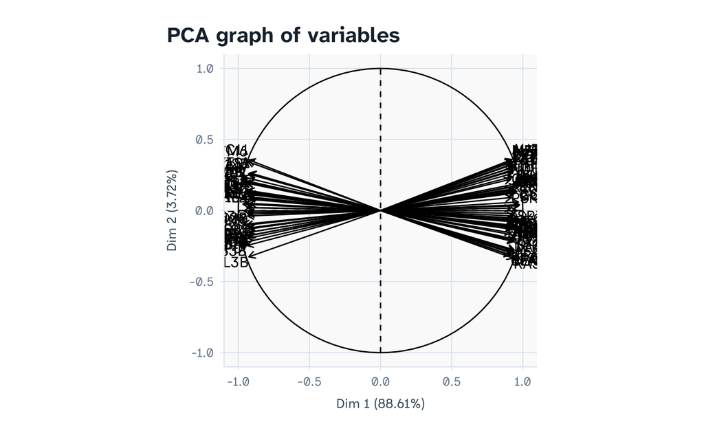

## Heatmap of most variable genes

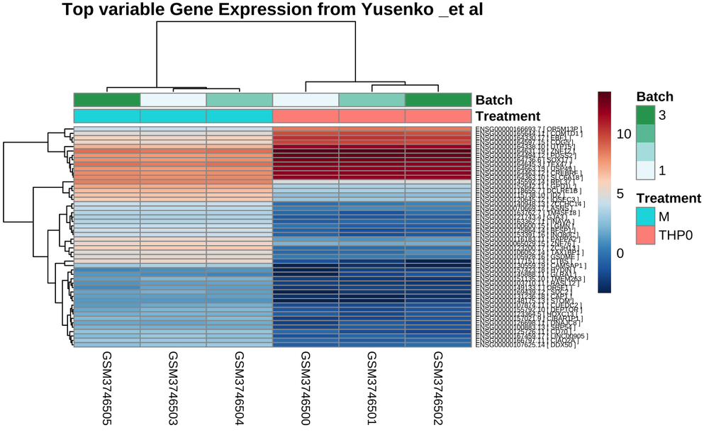

## Heatmap after training of differentially expressed genes Ctrl/Monensim

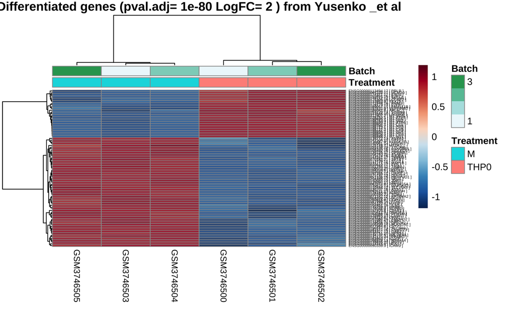

## Heatmap without scaling

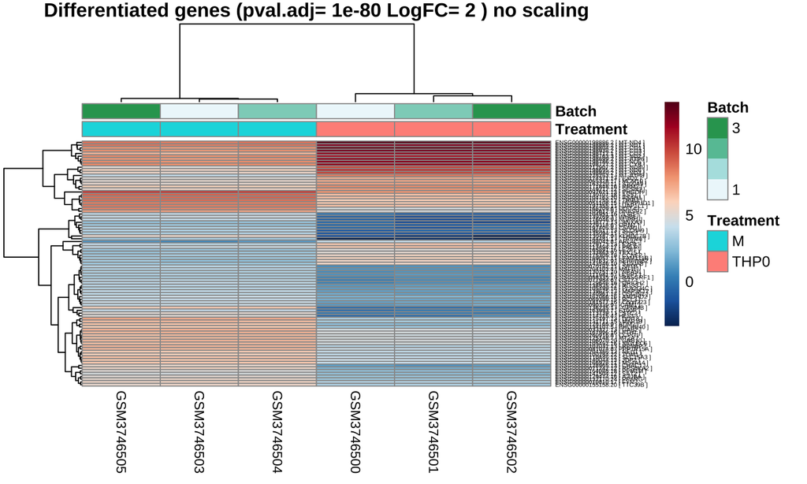

## TCGA data analysis

The Cancer Genome Atlas Breast Cancer (*Cell 2015*). Data vailable on CBioPortal.

https://www.cbioportal.org/datasets

**Breast cancer tumors profiling with RNA-seq**.

- Heterogeneous patients (sex, metastatis, etc..)
- Qualitative variable : **ER status** that define **patient groups**
- Normalisation with TMM
- Genes filtering
  - expressed on at least 1000 on all samples
  - expressed by at least 100 on 60% of samples of each group
- Analysis 1: **PCA**
- Analysis 2: **Unsupervised Clustering**

## PCA analysis

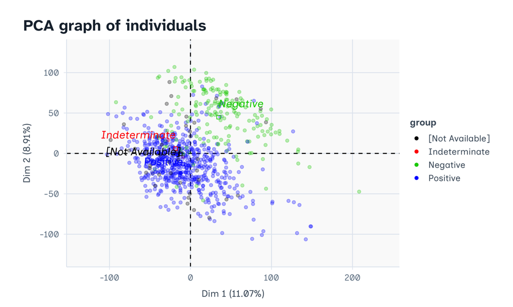

## Variance analysis

Eigenvalues

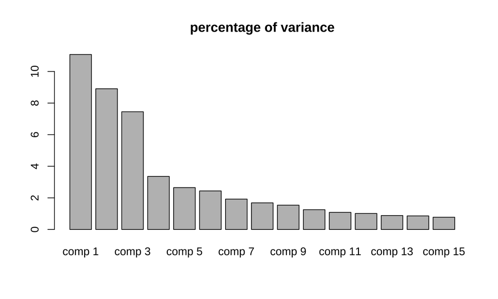

## Plot PCA on PC 2,3

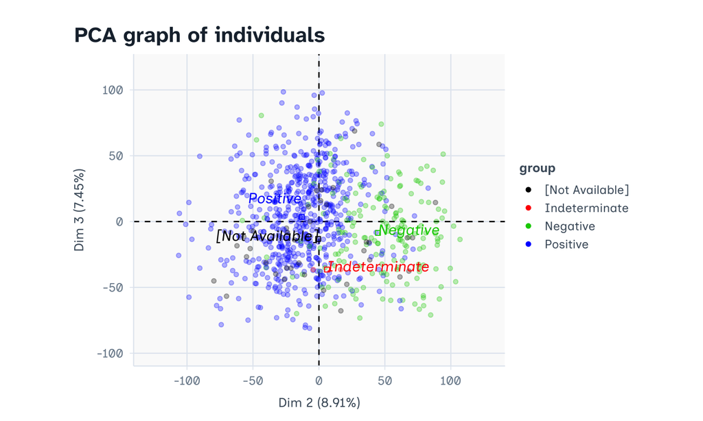

## Unsupervised clustering

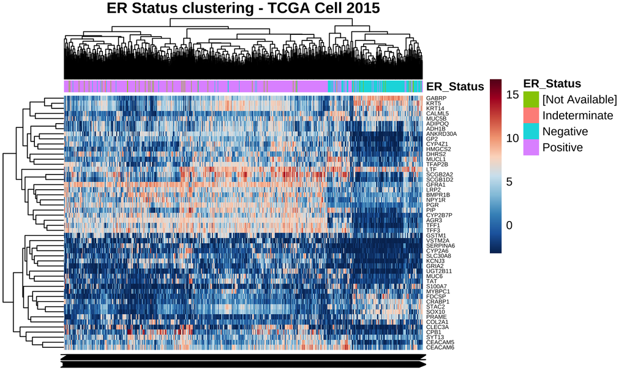

## Conclusion: Practical analysis of gene expression

- **Normalisation is essential**
- PCA to assess **data dimensionality**
- Supplementary variables are extremely important to **interpret partitions**
- **Clustering + heatmap** allow visualization of sample groups and link gene expressed in these groups.
- One can perform additional analysis with **other clinical variables**, HER status, PR status, molecular sub-types, survival, metastatic relapse…

## Single cell data analysis

## Single cell analysis

- Study of gene expression at the level of each **single cell**
- Study the **heterogeneity** of a tissue
- Identify **rare and unknown** cell types

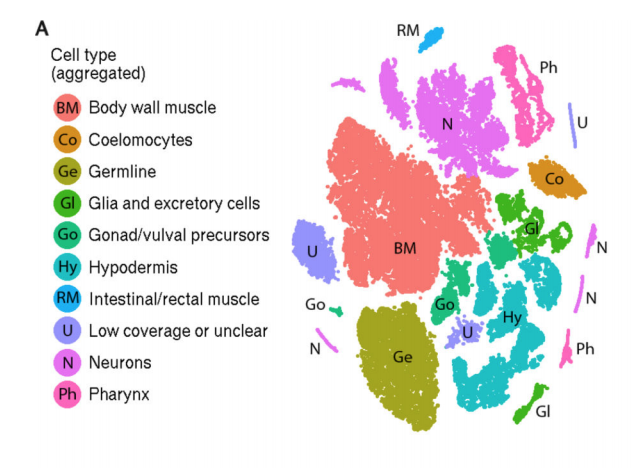

D’après Cao *et al.* 2017 (*Science*)

## From RNA-seq to Single Cell RNA-seq

[figure not shown]

## Different technologies

| Technology | Number of cells | Number of parameters | Pros | Cons |
| --- | --- | --- | --- | --- |
| Flow cytometry | 1k - 100k | 1-15 | Simple | N Limité |
| Mass spectrometry | 1k-100k | 20-50 | More parameters | N Limité |
| RNA FISH | ~100 | 1 | Résolution spatiale | Complex, low throughput |
| Multiplex FISH | 100-aine | ~100 | Spatial resolution | Complex to use and analyze |
| SS2 scRNA-seq | 100-1000 | ~20000 | High throughput | Sparse matrices |
| *Droplets* scRNA-seq | 100-1e6 | ~20000 | High throughput | Sparse matrices |

## Analyse 10X Genomics (Chromium)

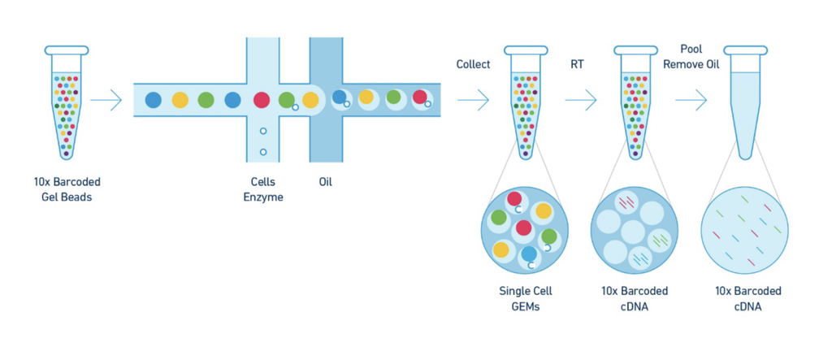

- Cells are **isolated in droplets** via oil emulsion. Cells associated with each droplet are **barcoded** with the corresponding bead code.
- The **Cell Barcode (16bp)** allows grouping **all transcripts from the same cell**
- The **Unique Molecular Identifier (12bp)** allows for precise counting of **unique copies of the same gene** (correcting for PCR biases).

## Count Matrix Generation

**After primary processing**, a count matrix `genes × cells` is obtained.

- column = one unique cell (barcode),
- row = one gene,
- value = the number of detected UMIs (RNA copies).

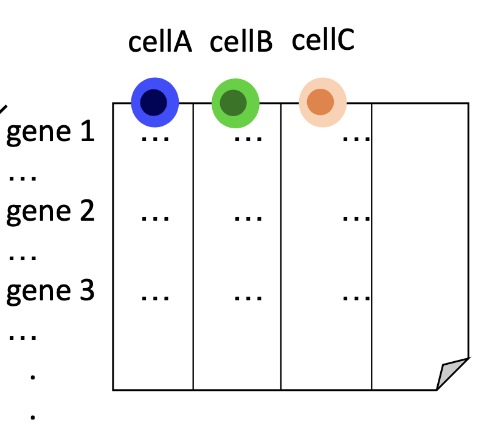

## Sequencing depth

## Normalisation

Each cell has:

- a different **total number of reads** (UMI),
- variable **sequencing depth**
- **effects** related to capture or technical noise.

If raw counts are compared directly, a cell with more reads will artificially appear “more highly expressed” than another. Normalization corrects this so that differences reflect **biologcal** rather than **technical** variation.

Log-normalization can be applied as follows:

\(E_{ij}^{norm} = \log_2\left(\frac{E_{ij}}{\text{TotalCounts}_i} \times 10^4 + 1\right)\)

- \(E_{ij}\) = count of gene \(j\) in cell \(i\)
- \(\text{TotalCounts}_i\) = total UMIs in cell \(i\)
- \(10^4\) = scale factor (arbitrary, to keep values around 1–10)

## Normalisation

1. Each cell is brought to a common base (10,000 reads).
2. A logarithm is applied to compress the dynamic range (prevent highly expressed genes from dominating).
3. Comparable values are obtained between cells and genes.

### Why is Normalization Crucial?

The following steps: PCA, clustering, and UMAP, use **distances between cells**.

Therefore, the values must be **comparable**. Without normalization, clusters would mainly reflect sequencing depth effects, not biology.

Log-transformation makes the distribution closer to a Gaussian, which improves linear methods like PCA.

## Next: Cell Clustering

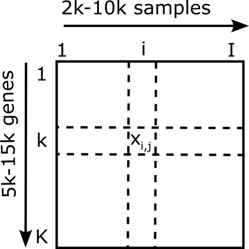

**Goal**: Identify groups of cells (clusters) sharing similar expression profiles. These clusters correspond to **cell types** or in **biological states**.

**Can hierarchical clustering be used on such a matrix ?**

## Next: Cell Clustering

**Can hierarchical clustering be used on such a matrix ?**

**No!**

The data is noisy and sparse (many zeros), making it nearly impossible to calculate Euclidean distances reliably.

Furthermore: for \(10^4\) cells, this implies \(10^8\) comparisons: **Impractical!**

Finally, it requires “cutting” the dendrogram, often arbitrarily.

## scRNA-seq Clustering Steps

In order for the analysis to work, we typically process the data as follows:

1. **Dimension Reduction (PCA)**: Cells are represented in a low-dimensional space (**20-50** dimensions in practice).
2. **Construction of a Neighborhood Graph (k-NN)**: Seurat calculates the k nearest neighbors for each cell.
3. **Identification of dense communities** (clusters) in the graph using the *Louvain* algorithm or a variant.

## Visualization of *Loadings*

```
## PC_ 1
## Positive:  CST3, TYROBP, LST1, AIF1, FTL
## Negative:  MALAT1, LTB, IL32, IL7R, CD2
## PC_ 2
## Positive:  CD79A, MS4A1, TCL1A, HLA-DQA1, HLA-DQB1
## Negative:  NKG7, PRF1, CST7, GZMB, GZMA
## PC_ 3
## Positive:  HLA-DQA1, CD79A, CD79B, HLA-DQB1, HLA-DPB1
## Negative:  PPBP, PF4, SDPR, SPARC, GNG11
## PC_ 4
## Positive:  HLA-DQA1, CD79B, CD79A, MS4A1, HLA-DQB1
## Negative:  VIM, IL7R, S100A6, IL32, S100A8
## PC_ 5
## Positive:  GZMB, NKG7, S100A8, FGFBP2, GNLY
## Negative:  LTB, IL7R, CKB, VIM, MS4A7
```

## Visualization of *Loadings*

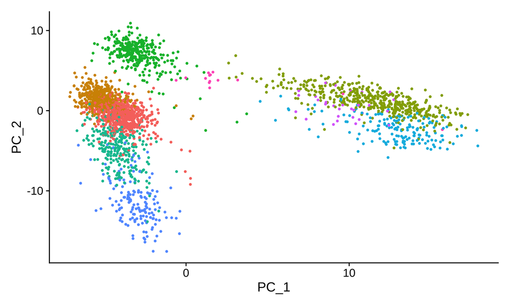

## Next: detecting *communities* with Louvain Algorithm

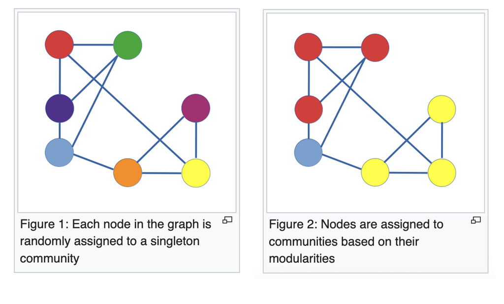

## Louvain Algorithm

The **Louvain algorithm** detects communities in a graph by seeking to **maximize modularity**, a comparison of the density of **internal connections** *vs* to those **between groups**:

1. each node is assigned to its **own cluster**,
2. The algorithm iteratively merges neighboring nodes if this **increases modularity**.

Once no local improvement is possible, it contracts communities into super-nodes and **repeats the process**.

*Leiden* is an **improvement** of Louvain: It fragments “poorly connected” clusters before merging them.

## I have clusters, what next?

To interpret the data, clusters are visualized. This will allow:

- To situate them **relatively to each other**
- To visualize their potential **compactness or heterogeneity**

Next, **differentially expressed (DE)** genes are sought:

- Between all clusters
- Between one cluster and the rest

By using **supervised clustering**. Goal: Interpret the clusters’ **biology (cell types)**.

## UMAP

**UMAP** (*Uniform Manifold Approximation and Projection*) is **a non-linear dimension reduction** method used to visualize complex data, such as single-cell data.

- It seeks to preserve both **local structure (close cells remain close)** and **global structure (general organization of groups)** by projecting data into 2D or 3D.

UMAP first constructs a **neighborhood graph** in high-dimensional space, then optimizes it to remain as similar as possible in the reduced space.

**Result:** a compact and intuitive map where biological clusters appear clearly separated.

## UMAP - Principle

The points are in 3D, but they are **spread over a 2-dimensional surface** rolled up in space (the “manifold”).

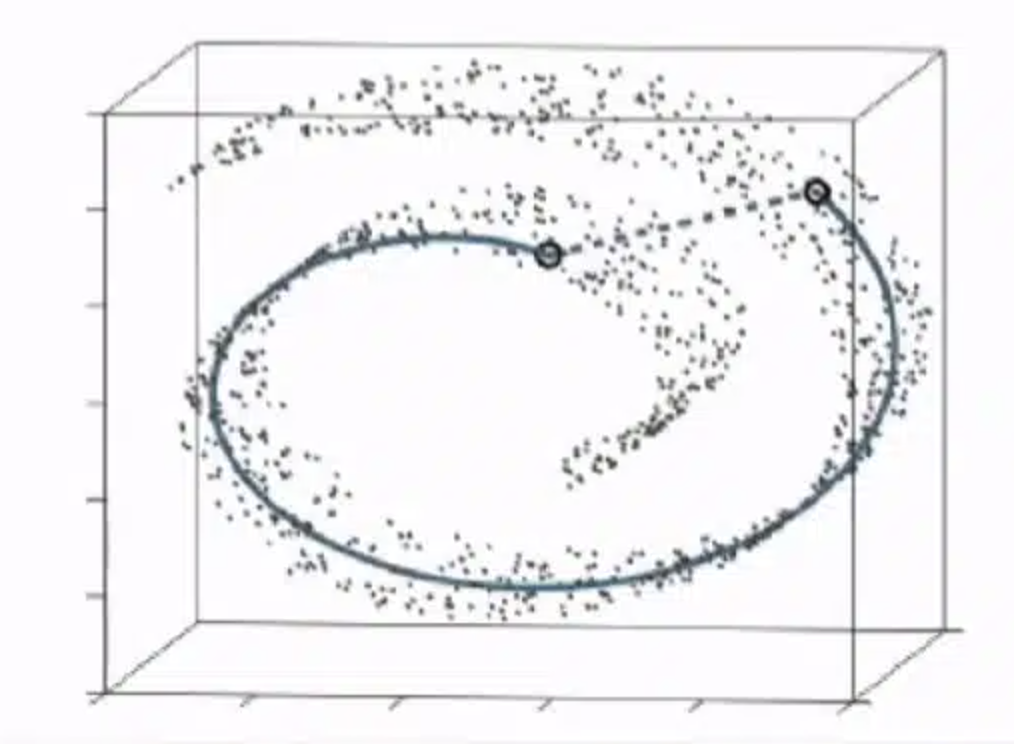

- The two circled points are close together in a straight line (the dashed line, Euclidean distance),
- They are very far apart if one follows the surface (the solid curve).

They are therefore **unrelated to each other**, and a good algorithm should **not bring them closer together**.

PCA, which projects linearly, flattens the roll and place them next to each other.

## UMAP

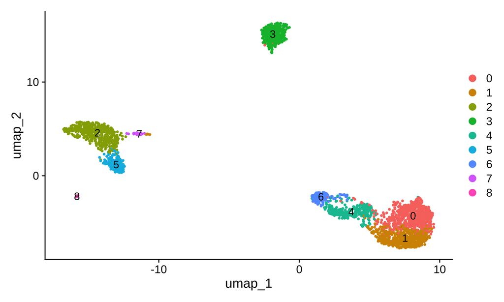

## UMAP 3D

[interactive chart not shown]

## Identification of Differentially Expressed Genes betwen clusters

|  | p_val | avg_log2FC | pct.1 | pct.2 | p_val_adj |
| --- | --- | --- | --- | --- | --- |
| LTB | 0.0000000 | 1.3908192 | 0.976 | 0.614 | 0.0000000 |
| IL32 | 0.0000000 | 1.2704226 | 0.925 | 0.429 | 0.0000000 |
| IL7R | 0.0000000 | 1.6709603 | 0.750 | 0.288 | 0.0000000 |
| LDHB | 0.0000000 | 1.1602192 | 0.953 | 0.583 | 0.0000000 |
| CD3D | 0.0000000 | 1.1421611 | 0.910 | 0.391 | 0.0000000 |
| HLA-DRA | 0.0000000 | -4.1473786 | 0.312 | 0.642 | 0.0000000 |
| AQP3 | 0.0000000 | 2.4457161 | 0.412 | 0.086 | 0.0000000 |
| HLA-DRB1 | 0.0000000 | -3.5754055 | 0.169 | 0.556 | 0.0000000 |
| CD74 | 0.0000000 | -2.6679572 | 0.793 | 0.861 | 0.0000000 |
| HLA-DPA1 | 0.0000000 | -3.3088371 | 0.239 | 0.578 | 0.0000000 |
| TPT1 | 0.0000000 | 0.5451457 | 0.995 | 0.983 | 0.0000000 |
| TYROBP | 0.0000000 | -5.1147890 | 0.128 | 0.487 | 0.0000000 |
| HLA-DPB1 | 0.0000000 | -3.2365922 | 0.279 | 0.598 | 0.0000000 |
| CD3E | 0.0000000 | 1.0888267 | 0.806 | 0.379 | 0.0000000 |
| HLA-DRB5 | 0.0000000 | -3.9225029 | 0.070 | 0.445 | 0.0000000 |
| CD2 | 0.0000000 | 1.6134181 | 0.607 | 0.223 | 0.0000000 |
| RPS12 | 0.0000000 | 0.4701642 | 1.000 | 0.991 | 0.0000000 |
| FCER1G | 0.0000000 | -4.4800394 | 0.099 | 0.444 | 0.0000000 |
| CYBA | 0.0000000 | -1.3072619 | 0.822 | 0.856 | 0.0000000 |
| TNFRSF4 | 0.0000000 | 3.8001506 | 0.191 | 0.015 | 0.0000000 |
| TRAT1 | 0.0000000 | 1.7950957 | 0.392 | 0.101 | 0.0000000 |
| RPS25 | 0.0000000 | 0.5029087 | 1.000 | 0.975 | 0.0000000 |
| RPS3 | 0.0000000 | 0.4104488 | 1.000 | 0.994 | 0.0000000 |
| FTL | 0.0000000 | -2.4391664 | 0.992 | 0.989 | 0.0000000 |
| RPS18 | 0.0000000 | 0.3868416 | 0.998 | 0.997 | 0.0000000 |
| CD40LG | 0.0000000 | 2.2474283 | 0.262 | 0.052 | 0.0000000 |
| RPS29 | 0.0000000 | 0.5385976 | 0.989 | 0.906 | 0.0000000 |
| JUNB | 0.0000000 | 0.6883859 | 0.974 | 0.884 | 0.0000000 |
| MT-CO1 | 0.0000000 | -0.4774982 | 0.998 | 0.993 | 0.0000000 |
| EEF1A1 | 0.0000000 | 0.3902384 | 1.000 | 0.989 | 0.0000000 |

[output cut: 8212 more lines]

## Gene expression visualisation

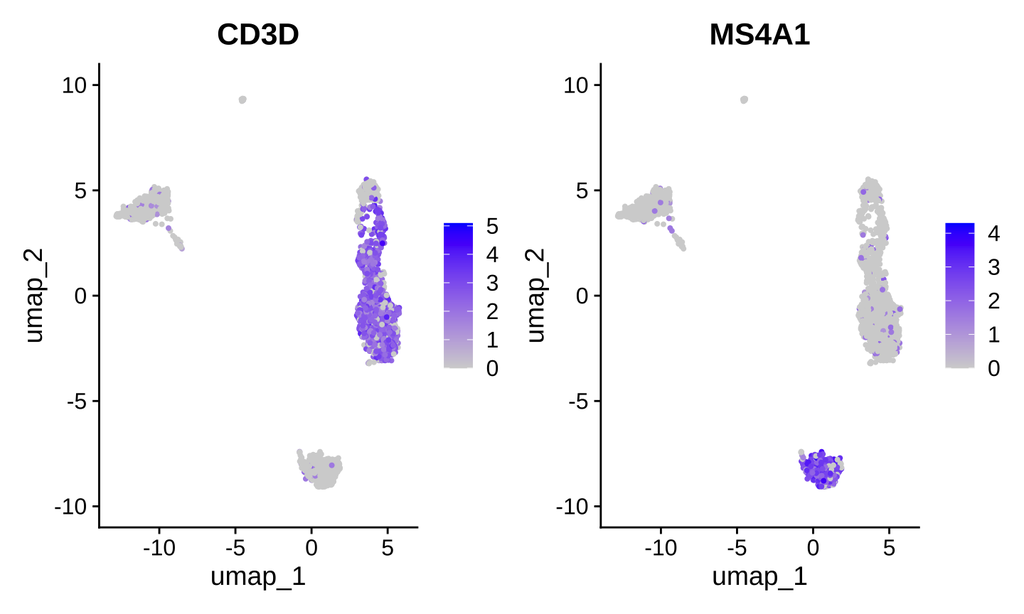

## Cell type inference

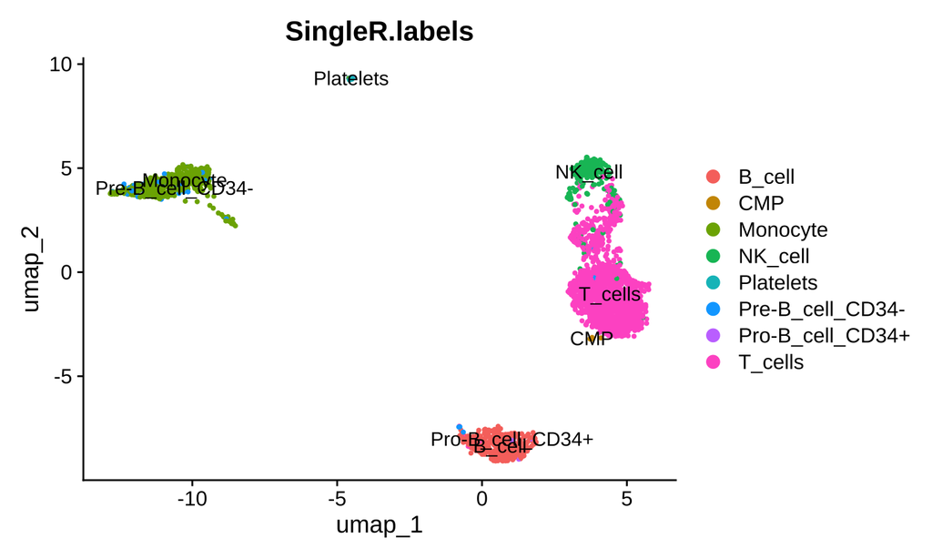

## Assignation of cell identity with SingleR

**SingleR** assigns cell identity based on **reference datasets (bulk or scRNA-seq)** called **Atlases**.

1. **The Similarity Metric:** Spearman Correlation. SingleR typically uses Spearman rank correlation. It compares the **rank** of gene expression rather than raw values.
2. This makes the method **robust to differences in technologies** (e.g., comparing TPM from bulk RNA-seq vs. UMI counts from 10x Genomics).
3. **Process:** For each single cell, it calculates the Spearman correlation with the mean expression profile of every sample in the reference dataset.

## Summary of Key Analysis Steps

1. **Import & QC**: Load count matrices and filter low-quality cells
2. **Normalization & Scaling**: Correct for differences in sequencing depth (Keep top 200 variable genes)
3. **Dimension Reduction**: Summarize data while preserving biological structure with ACP
4. **Clustering & Visualization**: Cluster with *Louvain* (graph clustering) and visualize with *UMAP*
5. **Identify differentially expressed genes** (DE) with supervised analysis
6. Identify cellular subpopulations with **Single Cell Atlases**

## General pointers

- **RStudio data analysis package**: https://posit.co/
- **Bioconductor**: R packages for biological data analysis: https://www.bioconductor.org/
- **FactominR** page by F. Husson: http://factominer.free.fr/index.html
- **The Cancer Genome Atlas** can be found on CBioPortal: https://www.cbioportal.org/
- **Gene Expression Omnibus** to find omics datasets associated with publications:
- An interesting Youtube video on **TCGA data analysis** using **AltAnalyze** software: https://www.youtube.com/watch?v=vZ2fhodfp78

## Specific single cell pointers

- Single Cell Galaxy Tutorial:

https://training.galaxyproject.org/training-material/topics/transcriptomics/tutorials/scrna-preprocessing-tenx/tutorial.html

- Satijat Seurat Pipeline:

https://satijalab.org/seurat/

- PBMC analysis Seurat pipeline demo

https://satijalab.org/seurat/v3.2/pbmc3k_tutorial.html

- Sanger Single Cell course

https://scrnaseq-course.cog.sanger.ac.uk/website/index.html

## Licence

Cette œuvre est mise à disposition selon les termes de la [Licence Creative Commons:](http://creativecommons.org/licenses/by-nc-nd/4.0/)  
Attribution - Pas d’Utilisation Commerciale - Pas de Modification 4.0 International (CC BY-NC-ND 4.0).

Copyright © Ghislain BIDAUT 2022-2026